# Module importation

```python
import numpy as np
import matplotlib.pyplot as plt
import math
from scipy.spatial import Delaunay
```

# 2D-CCPF Model

## Problem

Consider the 2D-CCPF model with Dirichlet boundary conditions : given a vector function $R=(R^m,R^c)$ and $u_0\in H^1_0(\Omega_m)$, find a vector function $u = (u^m, u^c)$ such as : \begin{equation} \begin{cases} \begin{aligned} S\frac{\partial u^m}{\partial t}-\nabla\cdot\left(\mathbb K\nabla u^m\right) &= -\alpha_{ex} \left(u^m-u^c\right)\delta_{y} +R^m \text{ in } \Omega_m\\ -\frac{\partial}{\partial x}\left(D\frac{\partial u^c}{\partial x}\right) &= \alpha_{ex}\left( {u^m}_{|y=0} -u^c\right)+R^c \text{ in } \Omega_c\\ u^m&=0\text{ on } \partial \Omega_m\\ u^c&=0\text{ on } \partial\Omega_c\\ u^m(0,\cdot) &= u_0\text{ on } \Omega_m \end{aligned} \end{cases} \end{equation}

In this implementation, we set all the constant values at $1$.

## Weak formulation

The weak formulation of semi-discretization is : given a function $u_0$ of $H^1_0(\Omega_m)$, find a sequence $(u_p)_{1\leq p\leq N}$ of $W$ such as : \begin{equation} \begin{cases} a_p(u_p,w) = \tau_p (R_p,w)+S(u^m_{p-1},w^m), \forall w\in W,\\ u^m_0 = u_0 \end{cases} \end{equation} where $a_p$ is a bi-linear form defined on $W\times W$ by : $a_p(v,w) = a^m_p(v,w)+a^c_p(v,w)$, with : \begin{equation} \begin{aligned} a^m_p(v,w) &= \int_{\Omega_m}S v^m w^m+\tau_p\int_{\Omega_m}\mathbb K \nabla v^m\cdot \nabla w^m+\tau_p\alpha_{ex}\int_0^L\left(v^m(x,0)-v^c(x)\right)w^m(x,0)\\ a^c_p(v,w) &=\tau_p\int_0^L D\frac{d v^c}{d x}\frac{dw^c}{dx} +\tau_p\alpha_{ex}\int_0^L \left(v^m(x,0) -v^c(x)\right) w^c(x)dx \end{aligned}. \end{equation}

# Meshes generations

For each $p$, we define

- the anistropic triangulation $\mathcal T_{ph}$ based on triangular, for porous media domain $\Omega_m$ as follows. First on the $y$-direction, we divide $\left[-\frac{1}{2}, \frac{1}{2}\right]$ into $m$ segments with $m+1$ points $y_i$, where : \begin{equation} \begin{aligned} y_i &= -\frac{1}{2} +\frac{\sin(\frac{i\pi}{m})}{2}, i = 0,1,\dots, \frac{m}{2}\\ y_i &=\frac{1}{2} -\frac{\cos{\left(\frac{i\pi}{m} -\frac{\pi}{2}\right)}}{2}, i = \frac{m}{2}+1, \dots, m \end{aligned} \end{equation}

Next, on $x$-direction, we divide $[0,1]$ into $n$ equal segments with $n+1$ points.

- the triangulation $\mathcal P_{ph}$ is a restriction of $T_{ph}$ on conduit line $\Omega_c$

```python
#@title Meshes generations
Nx, Ny = 8,8
x = np.linspace(0,1, Nx+1)
y1 = math.pi*np.arange(0, int(Ny/2)+1)/Ny
y1 = -0.5 + 0.5*np.sin(y1)
y2 = math.pi*np.arange(int(Ny/2)+1, Ny+1)/Ny - math.pi/2
y2 = 0.5-0.5*np.cos(y2)

y = np.concatenate((y1, y2))
#Define a grid
nodes = []
for xi in x:
  for yi in y:
    nodes.append([xi, yi])

nodes = np.array(nodes)
#********************************************************************
mesh_pm = Delaunay(nodes)
mesh_c = x
#********************************************************************
del x, y1, y2, y
```

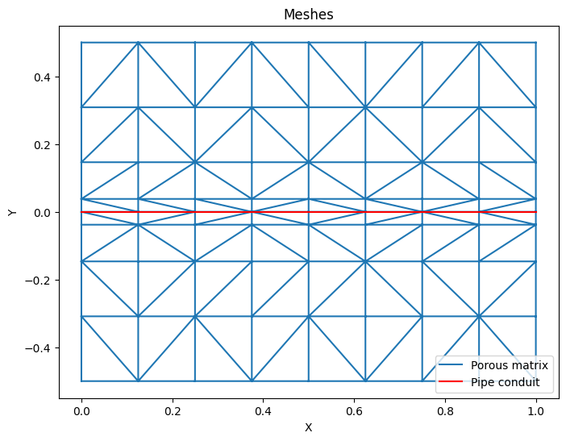

```python
#@title Plot meshes
plt.figure(figsize=(8, 6))
plt.triplot(nodes[:,0], nodes[:,1], mesh_pm.simplices, label="Porous matrix")
plt.plot(mesh_c, 0*mesh_c, "r-", label = "Pipe conduit")
plt.xlabel('X')
plt.ylabel('Y')
plt.legend()
plt.title('Meshes')
plt.show()
```

# Approximation spaces

# Data structuring

We need to structure our data. We define the table of :

- vertex coordinates of the meshes `coord`
- geometric connectivity `connect_geo`
- edges `edges`
- the boundadry edges `boundary_edges`
- shape functions `connect_shapes`

```python
#@title Table of vertix coordinates and elements
#Table of coordinates of mesh nodes
coord = mesh_pm.points
#Table of nodes per simplex
connect_geo = (mesh_pm.simplices).astype(int)
```

```python
#@title Table of edges and shape functions
#Table of edges contains the global number of each edge given an extremity
edges = []
#Table connect_shapes contains the edges per element
connect_shapes = np.zeros(connect_geo.shape)
n_edges = connect_geo.max()
num_edge = 0


# The goal is to create two tables : the table of edges and the table of connect_shapes.
# The table of edges is a 2D array and has a number_of_edges*2. Each row contains the two
# extremities of an edge and the row corresponds to the global number of this edge.

# The table of connect_shapes is also a 2D array with size number_of_elements*3. The row k
# correspons to k-th element of the mesh, and each column contains the global number of
# its three edge

#Loop over the elements
for k, triangle in enumerate(connect_geo):
  i = 0
  #Loop over the edge
  for edge in [[0,1], [0,2], [1,2]]:
    #There is no difference between an edge (12,15) and the edge (15,12)
    e = sorted(list(triangle[edge]))#

    #Get the number when this edge has already a global number
    edge_index = next((index for index, existing_edge in enumerate(edges) if (existing_edge == e)), None)
    #If no, we give them a number
    if edge_index == None:
      edges.append(list(e))
      connect_shapes[k, i] = num_edge
      num_edge += 1
    #and if yet,
    else:
      connect_shapes[k, i] = edge_index
    i += 1
    #Get

#Convert into array
edges = (np.array(edges)).astype(int)
connect_shapes = (connect_shapes).astype(int)
```

```python
#@title Table of boundary edges
unique, counts = np.unique(connect_shapes.flatten(), return_counts=True)
boundary_edges = (np.where(counts == 1)[0]).astype(int)
del unique, counts
```

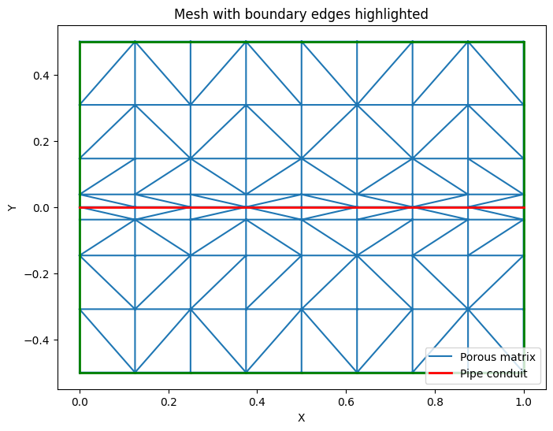

```python
#@title Plot boundary edges
plt.figure(figsize=(8, 6))
plt.triplot(coord[:, 0], coord[:, 1], mesh_pm.simplices, label = "Porous matrix")  # Plot triangles

# Highlight border edges in red
for edge_index in boundary_edges:
    edge_x = coord[edges[edge_index], 0]
    edge_y = coord[edges[edge_index], 1]
    plt.plot(edge_x, edge_y, 'g-', linewidth=2)  # Plot border edges in red

plt.plot(mesh_c, 0*mesh_c, "r-", linewidth=2, label="Pipe conduit")

# Label and display the plot
plt.xlabel('X')
plt.ylabel('Y')
plt.legend()
plt.title('Mesh with boundary edges highlighted')
plt.show()
```

## Triangle finite element

```python
def shape_functions(nodes):
  """Compute the coefficients of shape functions of an triangle

  Returns:
    coefficients:
        coefficients[i, j] : j-th coefficient of the i-th local shape function
  Note :
      the shape function is given by : coefficients[i, 0] + coefficients[i, 1]*x_1 + coefficients[i, 2]*x_2
  """
  #[0,1], [0,2], [1,2]
  milieu = np.zeros((3, 2))
  milieu[0,:] = (nodes[0,:] + nodes[1,:]) / 2
  milieu[1,:] = (nodes[0,:] + nodes[2,:]) / 2
  milieu[2,:] = (nodes[1,:] + nodes[2,:]) / 2

  #Define a matrix using the
  A = np.hstack((np.ones((3, 1)), milieu))
  I = np.eye(3)
  X = np.linalg.solve(A, I) #Solve AX = I
  coefficients = X.T
  return coefficients
```

```python
#@title Quadrature on triangle
#Refers to p. 221 of Ern's book Aide-mémoire Eléments finis about this
from math import sqrt
def quadrature_on_triangle(S):
  L = 7#Number of Gauss' points
  a1 = (6-sqrt(15))/21
  a2 = (6+sqrt(15))/21
  #This points is expressed in barycentric coordinates
  gauss_points = np.array([[1/3, 1/3, 1/3], [a1, a1, (1-2*a1)], [a1, (1-2*a1), a1],
   [(1-2*a1), a1, a1], [a2, a2, (1-2*a2)], [a2, (1-2*a2), a2], [(1-2*a2), a2, a2]])
  omega1 = S*(155-sqrt(15))/1200
  omega2 = S*(155+sqrt(15))/1200
  weights = np.array([9*S/40, omega1, omega1, omega1, omega2, omega2, omega2])
  return gauss_points, weights
```

```python
#@title Traingle area

def triangle_area(nodes):
  return 0.5*(nodes[1,:]-nodes[0,:]).dot((nodes[2,:]-nodes[0,:]))
```

```python
#@title Integrale
#Perfoms 2D integrale on a triangle
def integrale2D(triangle, f):
  """
  Returns a real value

  Inputs:
    f: a function
    S: area of a triangle

  Output:
    integrale:
  """
  gauss_points, weights=quadrature_on_triangle(triangle_area(triangle))
  #Convert coordinates from barycentric to ordinal coordinates
  gauss_points = gauss_points.dot(triangle)
  return f(gauss_points).dot(weights)
```

## Real segment finite element

```python
#@title Shape function on a segment

def shape_functions_1D(a,b):
  """
  Returns a 2*2 matrix, where a row contains the coefficients a and b of the polynomiale :
    a : constant term
    b :
  """
  A = np.array([[1, a], [1, b]])
  I = np.eye(2)
  X = np.linalg.solve(A,I)
  return X.T
```

```python
#@title Quadrature 1D
def quadrature_on_segment(a,b):
  m = (a+b)/2.0
  delta = b-a
  gauss_points = np.array([m+delta/2.0, m-delta/2.0, m])
  weights = np.array([delta/6.0, delta/6.0, 2*delta/3.0])
  return gauss_points, weights
```

```python
#@title Integrale 1D
#Perform 1D integrale of f on (a,b)
def integrale1D(a,b, f):
  """Returns a real value

  Input:
    a,b : two real such as a<b
    f : a 1 variable function

  Output : real number
  """
  gauss_points, weights = quadrature_on_segment(a,b)
  return f(gauss_points).dot(weights)
```

# Assembling

Let's denote by $\left(\varphi_i ^m \right)_{0\leq i\leq N}$ of $W^m_{ph}$ and by $\left(\varphi^c_i\right)_{0\leq i\leq P}$ basis of $W^c_{ph}$. The full discretization is equivalent to : given an approximation $u_0h$ of $u_0$, find a sequence $\left(u_{ph}\right)$ such that : \begin{equation} \begin{aligned} % a^m_{ph} (u_{ph}, w_{ph}) &= \tau_p \left(R^m_p, w^m_{ph}\right) + S\left(u^m_{ph},w^m_{ph}\right), \forall w^m_{ph} \in W^m_{ph}\\ % a^c_{ph} (u_{ph}, w_{ph}) &= \tau_p \left(R^c_p, w^c_{ph}\right), \forall w &\sum_{T\in \mathcal T _{ph}} \left[S\int_T u^m_{ph}w^m_{ph} + \tau_p \mathbb K \int_T \nabla u^m_{ph}\cdot \nabla w^m_{ph}+\tau_p\alpha_{ex} \int_T (u^m_{ph}-u^c_{ph})w^m_{ph}\delta_y\right] = \sum_{T\in \mathcal T_{ph}} \left[\tau_p \int_T R^m_p w^m_{ph} + S\int_T u^m_{p-1,h}w^m_{ph}\right]\\ &\sum_{E\in \mathcal P_{ph}} \left[\tau_p \int_E D\frac{d u^c_{ph}}{dx} \frac{d w^c_{ph}}{dx} + \tau_p\alpha_{ex}\int_E{(u^m_{ph}}_{|y=0} - u^c_{ph})w^c_{ph} \right] = \tau_p \sum_{E\in \mathcal P_{ph}} \int_E R^c_p w^c_{ph} \end{aligned} \end{equation}

Let $U^m_p = (u^m_{p1}, \dots, u^m_{pN})$ the coordinates of $u^m_{ph}$ in the basis $\left(\varphi_i ^m \right)_{0\leq i\leq N}$ and $U^c_p = (u^c_{p1}, \dots, u^c_{pP})$ the coordinates of $u^c_{ph}$ in the basis $\left(\varphi^c_i\right)_{0\leq i\leq P}$. The previous system is equivalent to the following :

\begin{equation} \begin{aligned} \sum_{i=0}^N u^m_{pi}\underline A_{ji} -\sum_{k=0}^P u^c_{pk} \underline B_{jk} &= \underline E_j, 0\leq j\leq N\\ \sum_{i=0}^N u^m_{pi}\underline C_{li} -\sum_{k=0}^P u^c_{pk} \underline D_{lk} &= \underline F_j, 0\leq l\leq P\\ \end{aligned} \end{equation} where

\begin{equation} \begin{aligned} \underline A_{ij} &= \sum_{T\in \mathcal T _{ph}} \left[S\int_T \varphi^m_i\varphi^m_j + \tau_p \mathbb K \int_T \nabla \varphi^m_i\cdot \nabla \varphi^m_j+\tau_p\alpha_{ex} \int_T \varphi^m_i \varphi^m_j\delta_y\right]\\ \underline B_{kj} &= \tau_p \alpha_{ex} \sum_{T\in \mathcal T_{ph}} \int_T\varphi^c_k \varphi^m_j \delta_y\\ \underline C_{ij} &= \tau_p\alpha_{ex} \sum_{E\in\mathcal P_{ph}} \int_E {\varphi^m_i}_{|y=0} \varphi^c_j dx\\ \underline D_{kj} &= \tau_p D\sum_{E\in \mathcal P_{ph}} \int_E \frac{d\varphi^c_k}{dx}\frac{\varphi^c_j}{dx} -\tau_p\alpha{ex} \sum_{E\in \mathcal P_{ph}} \int_E\varphi^c_k\varphi^c_j\\ \underline E_j &= \sum_{T\in \mathcal T_{ph}} \left[\tau_p \int_T R^m_p \varphi^m_{j} + S\int_T u^m_{p-1,h}\varphi^m_{j}\right] \\ \underline F_j &= \tau_p \sum_{E\in \mathcal P_{ph}} \int_E R^c_p w^c_{ph} \end{aligned} \end{equation}

This leads to the linear system defined by :

\begin{equation} \begin{pmatrix} \underline A & -\underline B\\ \underline C & \underline D \end{pmatrix} \begin{pmatrix} U^m_p\\ U^c_p \end{pmatrix} = \begin{pmatrix} \underline E\\ \underline F \end{pmatrix} \end{equation}

```python
#@title Assembling
def assembling():
  #Meshes --> mesh_pm, mesh_c
  #Nodes --> coord
  #Edges --> edges, boundary_edges
  #Triangles --> connect_geo, connect_shapes
  S, K, D, alpha_ex = 1,1,1,1
  tau_p = 1
  #
  N_edges = edges.shape[0]
  M_edges_on_x = len(mesh_c)-1
  A = np.zeros((N_edges, N_edges))
  B = np.zeros((N_edges ,M_edges_on_x))
  somme = 0
  for k, tri in enumerate(connect_geo):
    nodes = coord[tri,:]
    coefficients = shape_functions(nodes)
    #
    gauss_points, weights = quadrature_on_triangle(triangle_area(nodes))
    #Corresponding Gauss' points
    tri_ = gauss_points.dot(nodes)
    #delta_y
    delta_y = (tri_gp[:,1]==0).astype(float)
    # print(delta_y)
    #Add a col of 1 for matrix product
    tri_gp = np.hstack((np.ones((tri_gp.shape[0],1)), tri_gp))
    #loop edges
    for ni in range(3):
      i = connect_shapes[k,ni]#Get global number of tri's edges
      phi_m_ni = coefficients[ni,:].dot(tri_gp.T)
      dphi_m_ni = coefficients[ni,1:].reshape(2,1).dot(np.ones((1, tri_gp.shape[0])))#The gradient is constant
      for nj in range(3):
        j = connect_shapes[k,nj]#Get global number of tri's edges
        phi_m_nj = coefficients[nj,:].dot(tri_gp.T)
        dphi_m_nj = coefficients[nj,1:].reshape(2,1).dot(np.ones((1, tri_gp.shape[0])))#The gradient is constant
        A[i,j] += (S*phi_m_ni*phi_m_nj
                +tau_p*K * np.sum(dphi_m_ni * dphi_m_nj, axis=(0))
                +tau_p*alpha_ex *phi_m_ni*phi_m_nj*delta_y).dot(weights)
        # print(A[i,j])
      #Loop over the mesh_c
      for k in range(len(mesh_c)-1):
        coefficients1D = shape_functions_1D(mesh_c[k], mesh_c[k+1])
        phi_c = coefficients1D[0,:].dot(tri_gp[:,:2].T)
        B[i,k] += (phi_c*phi_m_ni*delta_y).dot(weights)
        #
```